# Statistical Learning Project

## Domain :

Healthcare

## Context:

Leveraging customer information is paramount for most businesses. In the case of an insurance company, attributes of customers like the ones mentioned below can be crucial in making business decisions. Hence, knowing to explore and generate value out of such data can be an invaluable skill to have.

## Attribute Information:

age: age of primary beneficiary

sex: insurance contractor gender, female, male

bmi: Body mass index, providing an understanding of body, weights that are relatively high or low relative to height, objective index of body weight (kg / m ^2) using the ratio of height to weight, ideally 18.5 to 24.9 children: Number of children covered by health insurance / Number of dependents

smoker: Smoking

region: the beneficiary's residential area in the US, northeast, southeast,

southwest, northwest.

charges: Individual medical costs billed by health insurance.

## Import the necessary libraries

```python
import numpy as np
import pandas as pd
import matplotlib.pyplot as plt
import seaborn as sns
import statsmodels.api as sm
import scipy.stats as stats
sns.set(color_codes = True)
%matplotlib inline
```

## Read the data as a data frame

```python
ins_df = pd.read_csv('insurance.csv') #import the data set named "insurance.csv"
```

```python
ins_df.head()    #It returned the top 5 rows from the dataframe as shown below.
```

|  | age | sex | bmi | children | smoker | region | charges |
| --- | --- | --- | --- | --- | --- | --- | --- |
| 0 | 19 | female | 27.900 | 0 | yes | southwest | 16884.92400 |
| 1 | 18 | male | 33.770 | 1 | no | southeast | 1725.55230 |
| 2 | 28 | male | 33.000 | 3 | no | southeast | 4449.46200 |
| 3 | 33 | male | 22.705 | 0 | no | northwest | 21984.47061 |
| 4 | 32 | male | 28.880 | 0 | no | northwest | 3866.85520 |

## Shape of the data

```python
print(ins_df.shape) # see the shape of the data
```

```
(1338, 7)
```

The 2D-dataframe is having 1338 rows and 7 columns.

## Data type of each attribute

```python
ins_df.info()
```

```
<class 'pandas.core.frame.DataFrame'>
RangeIndex: 1338 entries, 0 to 1337
Data columns (total 7 columns):
 #   Column    Non-Null Count  Dtype
---  ------    --------------  -----
 0   age       1338 non-null   int64
 1   sex       1338 non-null   object
 2   bmi       1338 non-null   float64
 3   children  1338 non-null   int64
 4   smoker    1338 non-null   object
 5   region    1338 non-null   object
 6   charges   1338 non-null   float64
dtypes: float64(2), int64(2), object(3)
memory usage: 73.3+ KB
```

```python
ins_df.dtypes.value_counts()
```

```
object     3
float64    2
int64      2
dtype: int64
```

The attribute 'sex','smoker' and 'region' is of type object which will need to be converted.Rest all other attributes are of int and float type. Also, all the attributes have no-null data.

## Checking the presence of missing values

```python
ins_df.isnull().sum()
```

```
age         0
sex         0
bmi         0
children    0
smoker      0
region      0
charges     0
dtype: int64
```

```python
ins_df.isnull().all()
```

```
age         False
sex         False
bmi         False
children    False
smoker      False
region      False
charges     False
dtype: bool
```

This demonstrates each value in the set is some value and no absent and invalid value present in the dataframe..

## 5 point summary of numerical attributes

```python
ins_df.describe()
```

|  | age | bmi | children | charges |
| --- | --- | --- | --- | --- |
| count | 1338.000000 | 1338.000000 | 1338.000000 | 1338.000000 |
| mean | 39.207025 | 30.663397 | 1.094918 | 13270.422265 |
| std | 14.049960 | 6.098187 | 1.205493 | 12110.011237 |
| min | 18.000000 | 15.960000 | 0.000000 | 1121.873900 |
| 25% | 27.000000 | 26.296250 | 0.000000 | 4740.287150 |
| 50% | 39.000000 | 30.400000 | 1.000000 | 9382.033000 |
| 75% | 51.000000 | 34.693750 | 2.000000 | 16639.912515 |
| max | 64.000000 | 53.130000 | 5.000000 | 63770.428010 |

```python
ins_df[['bmi','age','charges']].describe()
```

|  | bmi | age | charges |
| --- | --- | --- | --- |
| count | 1338.000000 | 1338.000000 | 1338.000000 |
| mean | 30.663397 | 39.207025 | 13270.422265 |
| std | 6.098187 | 14.049960 | 12110.011237 |
| min | 15.960000 | 18.000000 | 1121.873900 |
| 25% | 26.296250 | 27.000000 | 4740.287150 |
| 50% | 30.400000 | 39.000000 | 9382.033000 |
| 75% | 34.693750 | 51.000000 | 16639.912515 |
| max | 53.130000 | 64.000000 | 63770.428010 |

```python
#Attribute Age
print(ins_df['age'].describe()[['min','25%','50%','75%','max']])
#Attribute BMI
print(ins_df['bmi'].describe()[['min','25%','50%','75%','max']])
#Attribute Children
print(ins_df['children'].describe()[['min','25%','50%','75%','max']])
#Attribute Charges
print(ins_df['charges'].describe()[['min','25%','50%','75%','max']])
```

```
min    18.0
25%    27.0
50%    39.0
75%    51.0
max    64.0
Name: age, dtype: float64
min    15.96000
25%    26.29625
50%    30.40000
75%    34.69375
max    53.13000
Name: bmi, dtype: float64
min    0.0
25%    0.0
50%    1.0
75%    2.0
max    5.0
Name: children, dtype: float64
min     1121.873900
25%     4740.287150
50%     9382.033000
75%    16639.912515
max    63770.428010
Name: charges, dtype: float64
```

All the features are fine according to the numbers. ‘age’ feature is looking fine. ‘bmi’ feature is having the upper limit quite high. ‘children’ feature is fine and ‘charges’ feature is having a high range. Looking at the age column, data looks representative of the true age distribution of the adult population Very few people have more than 2 children. 75% of the people have 2 or less children

The charge is higly skewed as most people would require basic medi-care and only few suffer from diseases which cost more to get rid of

## Distribution of ‘bmi’, ‘age’ and ‘charges’ columns.

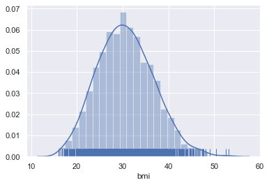

```python
sns.distplot(ins_df['bmi'], kde=True, rug=True);
```

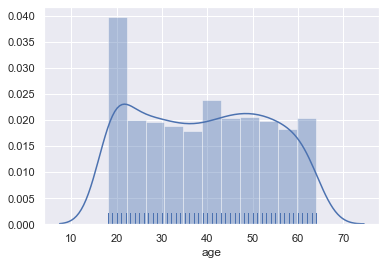

```python
sns.distplot(ins_df['age'], kde=True, rug=True);
```

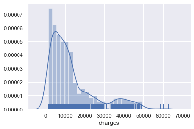

```python
sns.distplot(ins_df['charges'], kde=True, rug=True);
```

age - This attribute tells highest participation is done by the age around 20yrs old customers. Though the data is very very slightly more for higher age people is present.

bmi is approx normally distributed

Age seems distributed quiet uniformly

Charges are highly skewed

## Measure of skewness of ‘bmi’, ‘age’ and ‘charges’ columns

```python
ins_df[['bmi','age','charges']].cov()
```

|  | bmi | age | charges |
| --- | --- | --- | --- |
| bmi | 37.187884 | 9.362337 | 1.464730e+04 |
| age | 9.362337 | 197.401387 | 5.087480e+04 |
| charges | 14647.304426 | 50874.802298 | 1.466524e+08 |

```python
ins_df[['bmi','age','charges']].corr()
```

|  | bmi | age | charges |
| --- | --- | --- | --- |
| bmi | 1.000000 | 0.109272 | 0.198341 |
| age | 0.109272 | 1.000000 | 0.299008 |
| charges | 0.198341 | 0.299008 | 1.000000 |

```python
skewness = pd.DataFrame({"skewness":[ ins_df['bmi'].skew(),ins_df['charges'].skew(),ins_df['age'].skew()]},index=['bmi','age','charges'])
skewness
```

[output not shown]

Skew of bmi is very less

## Checking the presence of outliers in ‘bmi’, ‘age’ and ‘charges columns

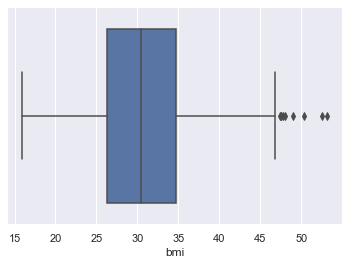

```python
sns.boxplot(x = ins_df['bmi'])
```

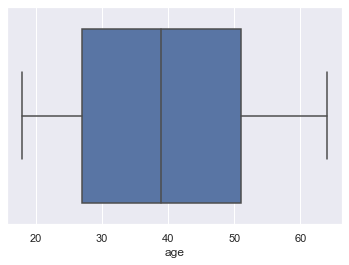

```python
sns.boxplot(x =ins_df['age'])
```

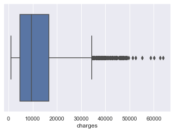

```python
sns.boxplot(x = ins_df['charges'])
```

```python
iqr = np.subtract(*np.percentile(ins_df['charges'], [75, 25]))
print(iqr)
```

```
11899.625365
```

```python
# identify outliers for charges

q25, q75 = np.percentile(ins_df['charges'], 25), np.percentile(ins_df['charges'], 75)
iqr = q75 - q25
cut_off = iqr * 1.5
lower, upper = q25 - cut_off, q75 + cut_off

outliers = [x for x in ins_df['charges'] if x < lower or x > upper]
print('Identified outliers for charges out of 1338: %d' % len(outliers))
```

```
Identified outliers for charges out of 1338: 139
```

```python
# identify outliers for bmi

q25, q75 = np.percentile(ins_df['bmi'], 25), np.percentile(ins_df['bmi'], 75)
iqr = q75 - q25
cut_off = iqr * 1.5
lower, upper = q25 - cut_off, q75 + cut_off

outliers = [x for x in ins_df['bmi'] if x < lower or x > upper]
print('Identified outliers for bmi out of 1338 records: %d' % len(outliers))
```

```
Identified outliers for bmi out of 1338 records: 9
```

```python
# identify outliers for age

q25, q75 = np.percentile(ins_df['age'], 25), np.percentile(ins_df['age'], 75)
iqr = q75 - q25
cut_off = iqr * 1.5
lower, upper = q25 - cut_off, q75 + cut_off

outliers = [x for x in ins_df['age'] if x < lower or x > upper]
print('Identified outliers for age out of 1338 records: %d' % len(outliers))
```

```
Identified outliers for age out of 1338 records: 0
```

-> bmi has less extreme values which tell very less people have bmi out the range of average people.

-> charges as it is highly skewed, there are quiet a lot of extreme values. Shows rarely people gave high charges.

-> No outlier in age attribute.

## Distribution of categorical columns (include children)

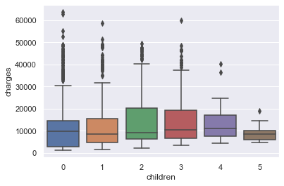

```python
sns.boxplot(ins_df['children'], ins_df['charges'])
```

we can see that extremly higher charges are paid by people having no child while least paid when having 5 children.

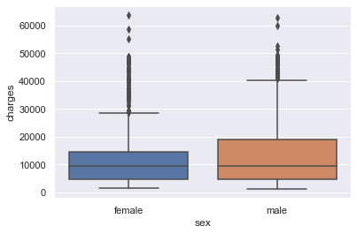

```python
sns.boxplot(ins_df['sex'], ins_df['charges'])
```

In both the male and female we see many among them had paid the extreme charges.Female has more outliers while males have a right skew telling more of them pay higher charges.

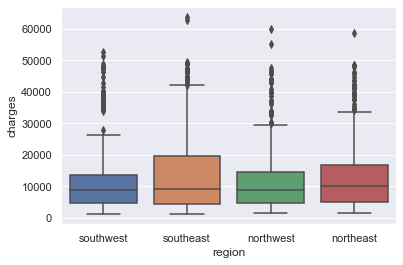

```python
sns.boxplot(ins_df['region'], ins_df['charges'])
```

Each location is having some extreme cases.Though southeast customers pay higher charges more.

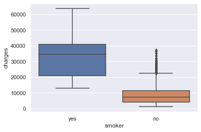

```python
sns.boxplot(ins_df['smoker'], ins_df['charges'])
```

Smokers pay higher medical costs billed by health insurance than the non-smokers.However, there are some outliers exists in the nonsmoker who pay higher charges.

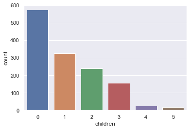

```python
sns.countplot(ins_df['children'])
```

More customers are not having children while very less have 5 children

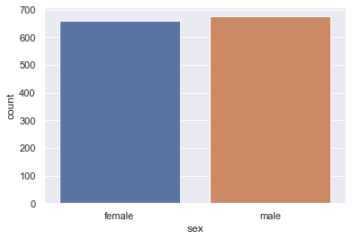

```python
sns.countplot(ins_df['sex'])
```

The gender ratio of insurance contractor is not significantly different.

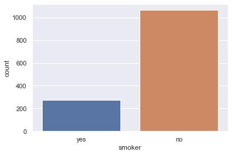

```python
sns.countplot(ins_df['smoker'])
```

The count of non-smokers is quite high than the smokers in the sample

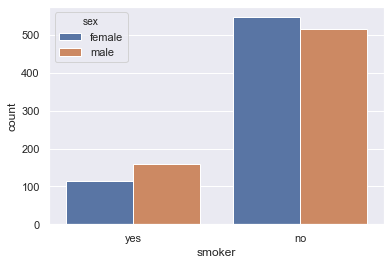

```python
sns.countplot(ins_df['smoker'],hue =ins_df['sex'])
```

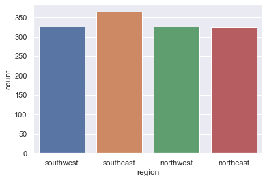

```python
sns.countplot(ins_df['region'])
```

Instances are distributed evenly accross all regions.

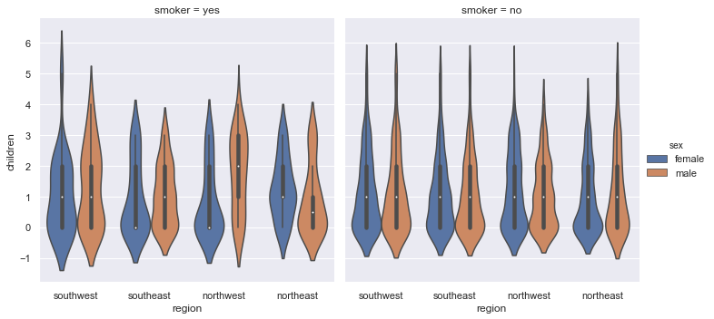

```python
sns.catplot(x="region",
               y = "children",
               hue="sex",
               col="smoker",
               data=data,
               kind="violin");
```

## Pair plot that includes all the columns of the data frame

we need to use Label encoding the variables before doing a pairplot because pairplot ignores strings

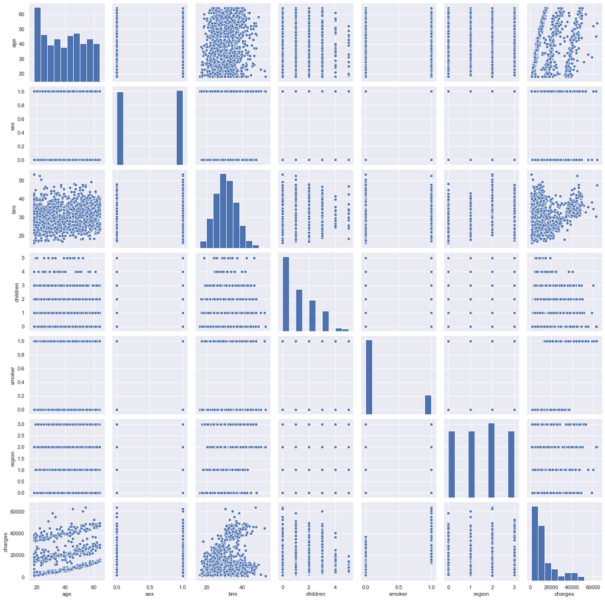

```python
from sklearn.preprocessing import LabelEncoder
import copy

ins_df_encoded = copy.deepcopy(ins_df)
ins_df_encoded.loc[:,['sex', 'smoker', 'region']] = ins_df.loc[:,['sex', 'smoker', 'region']].apply(LabelEncoder().fit_transform)
sns.pairplot(ins_df_encoded)
```

Between ‘age’ and ‘charges’, there is no clear relationship, though there seem to be 3 lines of positive relationship between them. It means, there are 3 sets of charges which increase gradually with age.

No clear relation between ‘age’ and ‘children’ either.

The range of ‘bmi’ decreases as children increases, however there are some extreme values in ‘bmi’ for children value 5.

There is a little positive relation between ‘bmi’ and ‘charges’, although the plot is a cloud on initial values of ‘charges’.

The range of ‘charges’ decreases as the value of ‘children’ increases.